# 시계열 기말 발표

- 단변량 전력사용량 예측 모델
- 통계학과 이민우

# 발표 순서

1. 데이터
   1. 데이터 설명
   2. 데이터 전처리
2. 시도표 설명
3. 모형 적합 과정 및 정상화
4. 적합 결과

# 1. A. 데이터 설명

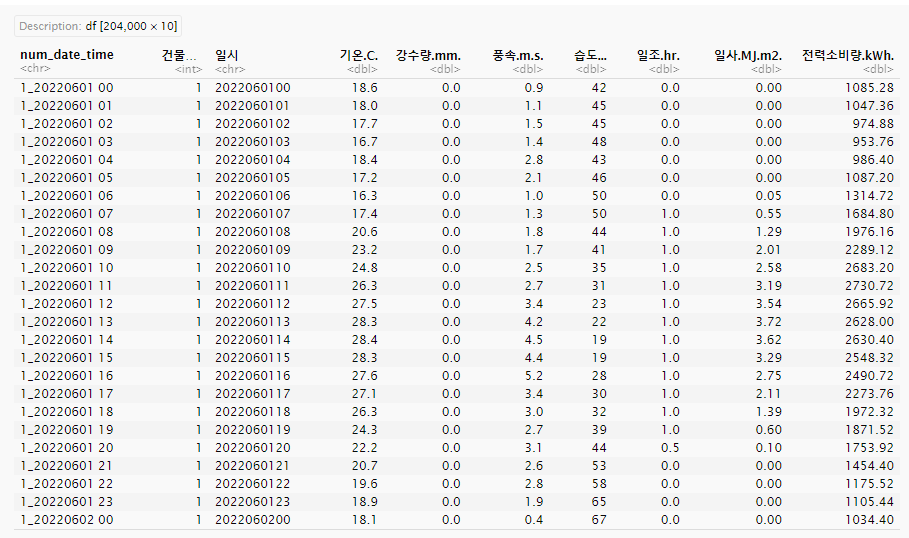

- DACON에서 주최된 **2023 전력사용량 예측 AI 경진대회** 에서 한국에너지공단이 제공한 훈련 데이터 셋이다.
- 데이터 칼럼은 100개의 건물들의 2022년 6월 1일부터 2022년 8월 24일까지의 시계열 데이터로 기온, 강수량, 풍속, 습도, 일조, 일사 정보 등이 있으며 **전력사용량**을 포함하고 있다.
- 그 중에서 **전력사용량** 중심으로 시계열 데이터 분석을 진행하고자 하며 하루 전력 사용량 예측 모델을 만들어 보고자 한다.

# 1.B. 데이터 전처리

`-` 데이터 프레임 생성

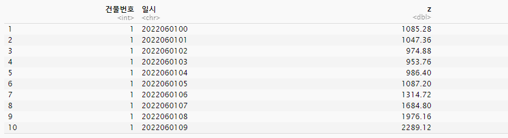

`-` 결측치 확인 및 데이터 보간

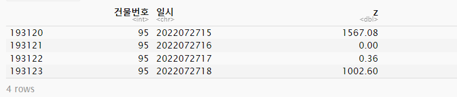

- 전력사용량 변수에서 결측치는 존재하지 않음
- 다만 유일하게 0으로 나온 값이 존재
- 193121, 193122의 해당되는 값은 파악할 수 없는 이유로 제대로 전력사용량이 측정되지 않은 것으로 보임
- 이 두 변수는 앞전 변수와 뒤 변수의 평균으로 보간하도록 하겠음

`-` train/ test set 생성

# 2. 시간별 전력사용량 시도표

`-` train set의 시도표

- 100개의 건물 전력사용량의 합을 나타내어 시도표를 생성

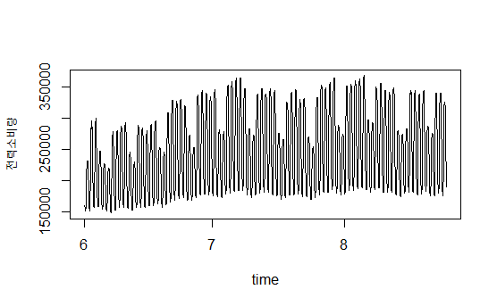

- 계절성분과 추세성분

# 3. 모형 적합 과정 및 정상화

`-` 요일별 하루 총 전력사용량

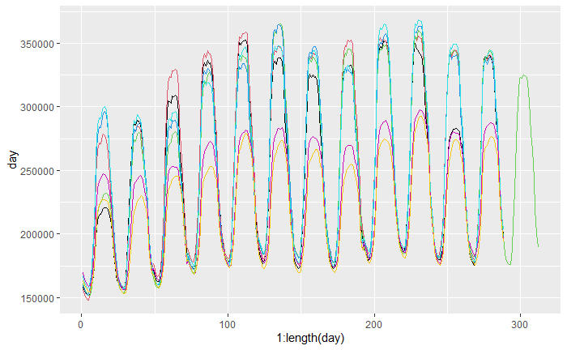

- 아래의 요일별로 묶은 전력사용량 그래프를 통해 변화폭이 요일별로 큰 차이가 있는 것을 알 수 있음

`-` 요일별 평균과 분산

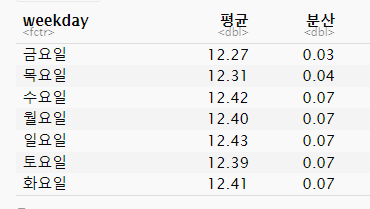

**그렇다면 그룹을 나누는게 좋아보인다.**

- 수준 차이가 큰 2 개 그룹으로 나누어 적합
- 요일별 나누어 적합
- 구분하지 않고 적합

`-` 4. 모형적합의 과정

- 분산안정화
- 시도표 확인
- 계절성분 제거
- 단위근 검정
- 추세성분 제거
- ARIMA 모형적합
- 예측결과 확인

# 3.A. 2개 그룹으로 적합

- group1 : 목요일, 금요일 전력사용량
- group2 : 나머지 요일

`-` 분산안정화

- group1

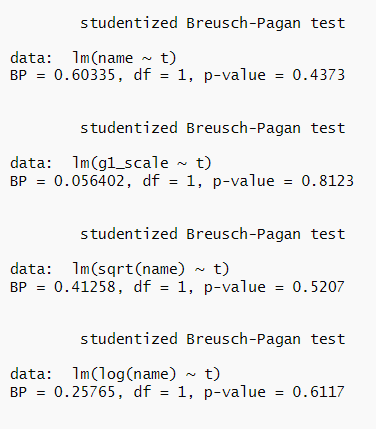

- group2

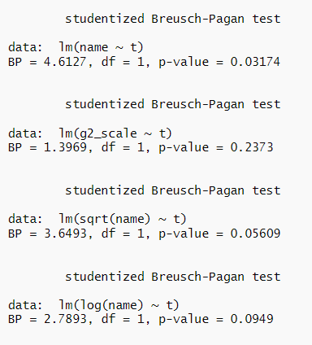

- 두 그룹 모두 BOXCOX 변환이 유의확률이 제일 크게 나왔음

`-` 시도표 및 ACF, PACF

- group1

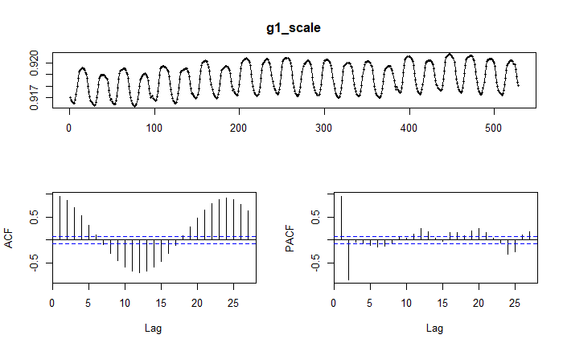

- group2

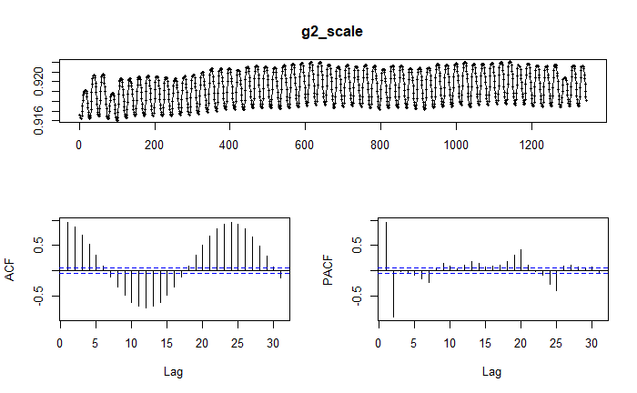

- 둘다 동일하게 추세와 같은 주기를 가진 계절성분을 보임
- ACF와 PACF도 동일한 양상을 띄고 있음
- 우선 계절차분을 진행

`-` 계절차분

- group1

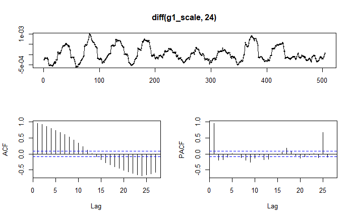

- group2

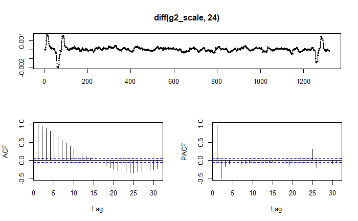

`-` 단위근 검정

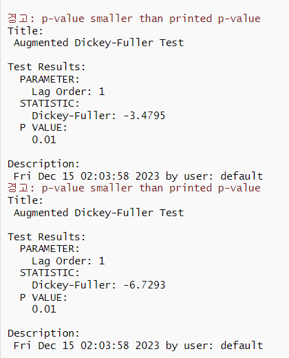

`-` 승법형 계절 ARIMA 모형 $$ (1-\phi B)(1-B^{24})(1-B)(Z_t-\mu) = (1-\Theta B^{24}) $$

`-` fit arima

- group1

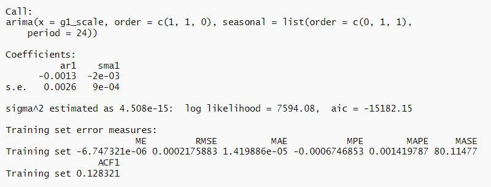

- group2

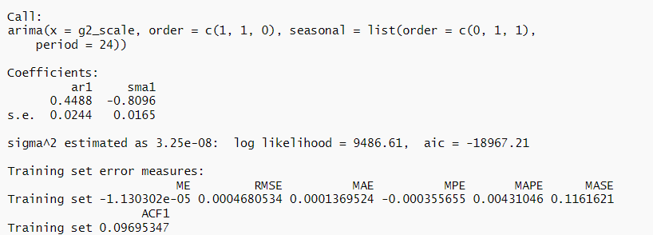

`-` 잔차

- group1

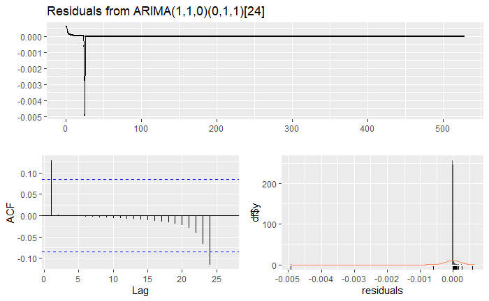

- group2

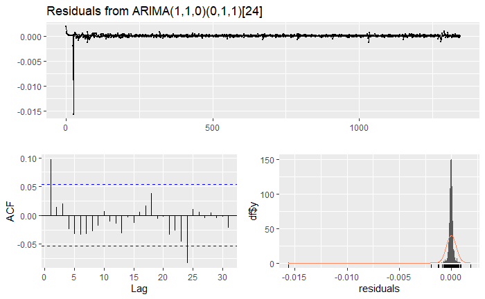

# 3.B. 요일별 시도표 및 모형 적합

`-` 일요일

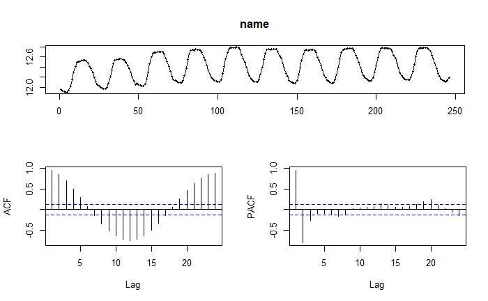

- 24주기의 계절성분이 시도표를 통해 확인되어짐
- PACF에서 2시차까지 기각역을 벗어남
- 계절 차분을 진행

`-` 계절차분

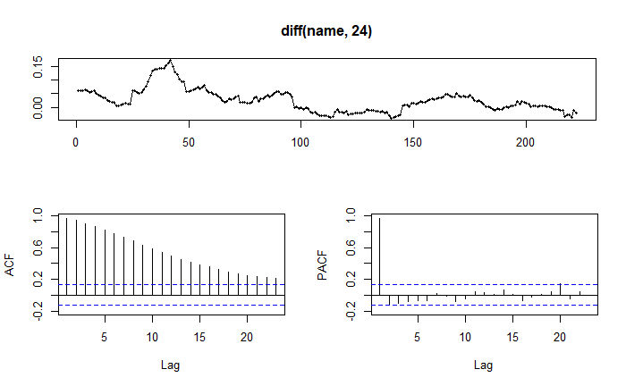

- ACF가 천천히 감소
- PACF는 1차시에 절단

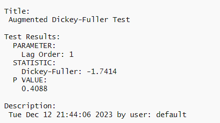

- 단위근 검정을 통해 귀무가설을 기각하지 못함
- 차분이 필요하다

`-` 추세차분

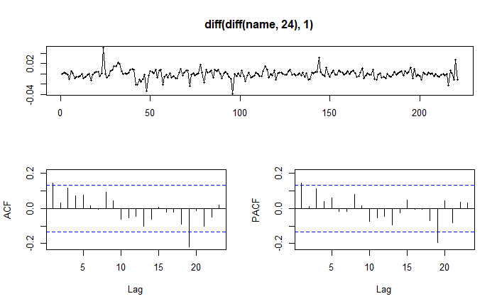

`-` 모형적합

`-` ARIMA(1,1,0)(0,1,1)[24] 모형 적합

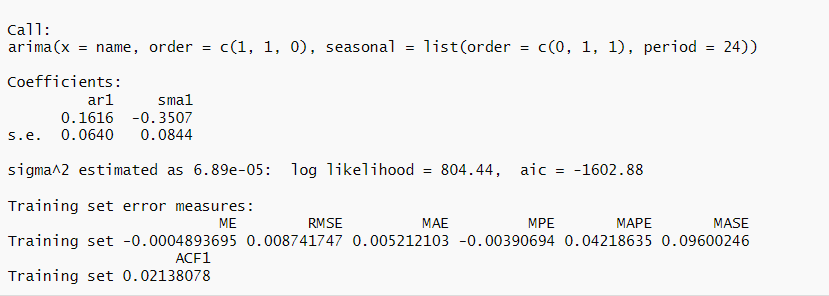

`-` auto ARIMA

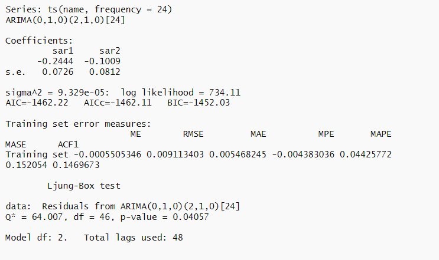

$$ (1-\phi B)(1-B^{24})(1-B)(Z_t-\mu) = (1-\Theta B^{24})\epsilon_t $$

`-` 잔차분석

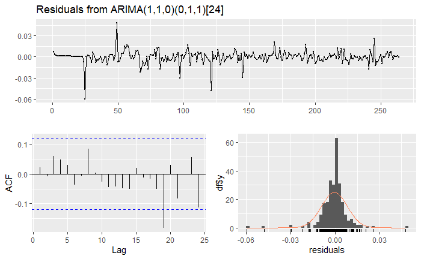

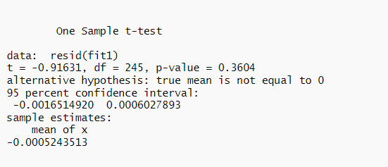

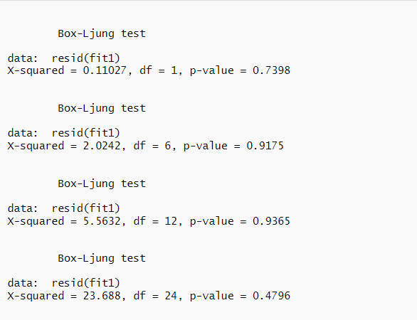

- $H0 : \rho1=...=\rho_k=0$
- $H1 : \rho1=...=\rho_k\ne0$
- 전부 유의하지 않음, 귀무가설 기각하지 않음

`-` 월요일 ~ 토요일

# 4. 적합결과

`-` 테스트 셋과 비교

- 검정선 : 실제 값
- 보라선 : 2그룹 예측치
- 빨간선 : 요일별 그룹 예측치
- 파란선 : 베이스모델(autoarima,요일별분류x)

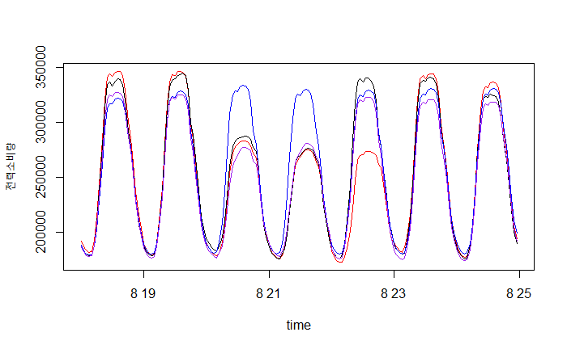

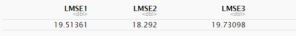

1. 요일별 적합
2. 2개 그룹 적합
3. 구분없이 적합